# Setting up a GitRepository

Adam

2022-06-21

### knitr

[knitr](https://yihui.org/knitr/) is a package for dynamic report generation that enables the integration of R code into LaTeX, LyX, HTML, Markdown, AsciiDoc, and reStructuredText documents. The purpose of knitr is to allow reproducible research in R through the means of literate programming. Additional extensions also exist for [python](https://rstudio.github.io/reticulate/articles/r_markdown.html) support. knitr is officially supported by [R Studio](https://support.rstudio.com/hc/en-us/articles/200552056-Using-Sweave-and-knitr) and can be executed to generate a HTML, PDF, or Word version of an R Markdown.

[figure not shown]

When writing a report, I recommend using [RMarkdown](https://rmarkdown.rstudio.com/lesson-2.html) to save and execute code in a format that lends itself to generating quality reports that can be shared with collaborators or in a GitRepository. Instructions for how to format can be found [here](https://www.rstudio.com/wp-content/uploads/2015/03/rmarkdown-reference.pdf)

[figure not shown]

### Git

[git](https://git-scm.com/) is an open source version control system, however, most users are likely familiar with [Github](https://github.com/) a great online tool for storing code and sharing with collaborators and/or the public. For daily work, however, I prefer to use [GitHub Desktop](https://desktop.github.com/), a graphical user interface for daily updates.

Begin by [creating a new repository](https://docs.github.com/en/desktop/installing-and-configuring-github-desktop/overview/creating-your-first-repository-using-github-desktop) in whatever working directory you wish to keep your files stored.

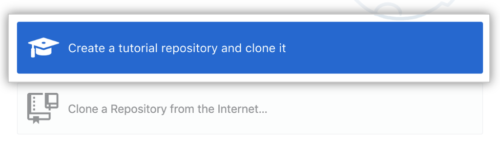

Doing so enables you to record any changes made to the repository, changes to scripts, updated notes, removed files, etc.

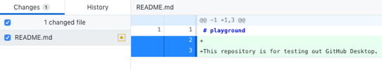

To commit changes that have been made, you will need to generate a *Summary* of the changes made and corresponding *Description*.

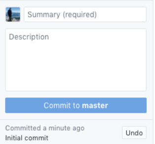

By committing the changes you confirm that any changes made to the files in your repository are saved. These changes are then also saved and recorded in the repositories *History*.

[figure not shown]

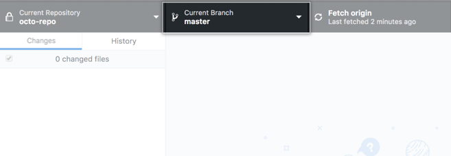

Branches can correspond can exist for any purpose, but one simple application is to ensure that each collaborator has their own branch. In this way, all collaborators can work on a project together, share the change without interfering with anyone else’s progress. When ready to share your progress with others, you can [**Push**](https://docs.github.com/en/desktop/contributing-and-collaborating-using-github-desktop/making-changes-in-a-branch/pushing-changes-to-github) your branch to the GitHub repository. This will upload the repository and all changes to the online storage so that other collaborators can see what you’ve done. If they wish to download a branch they can instead [**Pull**](https://docs.github.com/en/pull-requests/collaborating-with-pull-requests/proposing-changes-to-your-work-with-pull-requests/creating-a-pull-request) from the GitHub repository to their local computer.

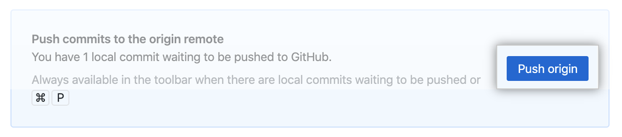

When a new branch has been uploaded that differs from the main, a [**Pull Request**](https://docs.github.com/en/pull-requests/collaborating-with-pull-requests/proposing-changes-to-your-work-with-pull-requests/about-pull-requests) will be generated. Changes between two branches can be synchronized by [**Merging**](https://docs.github.com/en/pull-requests/collaborating-with-pull-requests/addressing-merge-conflicts/resolving-a-merge-conflict-on-github). In this process Git will compare each document and determine whether they can be successfully merged without conflict. In the case of a file removal or addition, this change will proceed un-interrupted. However, when there is a conflict, such as within the contents of a file, collaborators will be notified and asked to resolve the conflict. In the following example, Git highlights the specific lines of text that conflict.

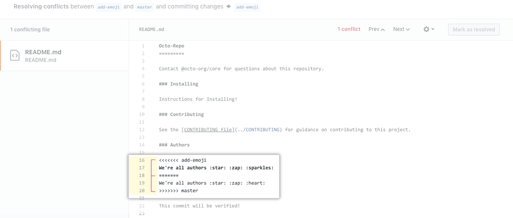

Once resolved, the two branches will be merged and the resulting synchronized brach is available for all collaborators to pull from and continue their work.

[figure not shown]

### Repository Structure

How you choose to structure your repository will depend on you and there are numerous ways that repositories can be structured. The most important part is to make sure that you can easily navigate and explain how your repository is structured. There are many [best practices](https://medium.com/code-factory-berlin/github-repository-structure-best-practices-248e6effc405), some of which include an initial *README* file that describes the purpose and structure of your repository; generating *log files* to describe what was done or how results were generated; and *staging directories* to store files that require manipulation in isolated of the originals and prior to finalization.

I use the following structure to make it easy to find and link to documents. Here are some examples of how I structure my repository. If this is your first time opening this template repository, you can either execute each run “Ctrl+Shift+Enter” or run all the chunks “Ctrl+Alt+R”. By separating work into chunks with R Markdown you can more easily annotate and segment your analysis into step.

```r
## Data
# store raw data and avoid altering files
dir.create(c("./data/raw"), showWarnings = FALSE, recursive = TRUE)
# store intermediate data for user manipulation
dir.create(c("./data/intermediate"), showWarnings = FALSE, recursive = TRUE)
# store final data for use in other documents
dir.create(c("./data/final"), showWarnings = FALSE, recursive = TRUE)
```

```r
# store protocols and information concerning, sampling, labwork, etc.
dir.create(c("./documentation/protocol"), showWarnings = FALSE, recursive = TRUE)
# store any references, in particular save all references in a single BibTex format
dir.create(c("./documentation/references"), showWarnings = FALSE, recursive = TRUE)
# write the bibtex file and save package citations
citPkgs <- names(sessionInfo()$otherPkgs)
knitr::write_bib(citPkgs, file="./documentation/references/references.bib")
```

```r
# save workflow as scripts and use a prefix to identify the order of operation, e.g. 01-initialize.Rmd
dir.create(c("./scripts/analysis"), showWarnings = FALSE, recursive = TRUE)
# save miscellaneous scripts that can be called on during the workflow, e.g. plot_table.R
dir.create(c("./scripts/functions"), showWarnings = FALSE, recursive = TRUE)
```